# `Linear Regression`

Used to find Linear Relationship between dependent and one or more independent variables  
`Linear Regression` is a `Supervised Learning Algo` => `solves Regression problems` where we try to predict a `Continuous Variable`

Linear Regression can be further classified into two types:

1. `Simple Linear Regression`
2. `Multiple Linear Regression`

# 1. Simple Linear Regression (`SLR`)

It is the simplest model in machine learning. It models the linear relationship between the independent and dependent variables.

`This application of Linear Regression is based on the TV and Sales data`

- In data we have one `Independent or Input Variable` which represents `TV`, `denoted by X`
- In data we have one `Dependent or Output Variable` which represents `Sales`,`denoted by y`  
  I am trying to build a Linear Relationship between these variables. This linear relationship can be modelled by mathematical equation of the form:-

  ```
                 Y = β0  + β1X    -------------   (1)
  ```

In this equation:

- `X` is `Independent Variables`
- `Y` is `Dependent Variables`
- `β1` is `Coefficient for independent variable`
- `β0` is `Constant Term`
- `β0` and `β1` are called `Parameters of Model`

For simplicity, compare above equation with basic linear equation of form:-

```
               y = mx + c       -------------   (2)
```

- `m` = `β1` => `Slope` of line
- `c` = `β0` => `Intercept` of line

In this Simple Linear Regression Model, I am trying to fit a line which estimates Linear Relationship between X and Y  
So, the question of fitting reduces to estimating the parameters of the model β0 and β1

# Ordinary Least Square Method

One can draw a scatter plot between X and y which shows relationship between them

`My task is to find a line which best fits this scatter plot This Line will help us to predict value of any Target variable for any given Feature variable This line is called **Regression line**`

`We can define an error function for any line. Then, the Regression Line is one which minimizes error function, such an error function is also called a Cost function`

By below chart you might understand more clearly

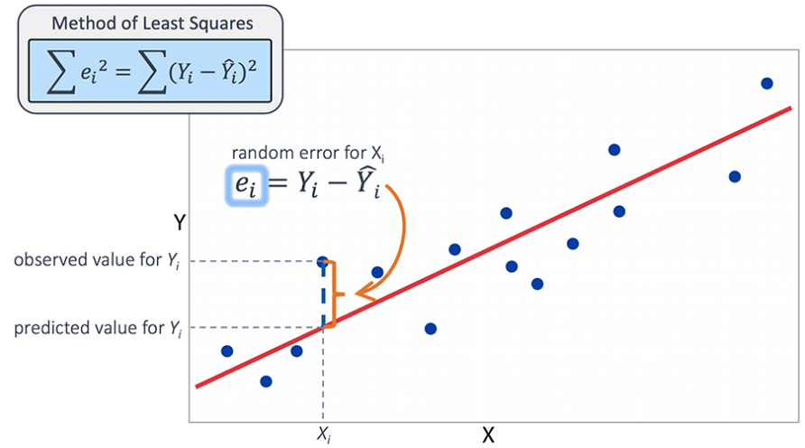

```python
# This Python 3 environment comes with many helpful analytics libraries installed
# It is defined by the kaggle/python Docker image: https://github.com/kaggle/docker-python
# For example, here's several helpful packages to load

import numpy as np # linear algebra
import pandas as pd # data processing, CSV file I/O (e.g. pd.read_csv)
```

# Understanding the Data Let's start with the following steps:

- Importing data using the pandas library
- Understanding the structure of the data

```python
df = pd.read_csv('advertising.csv')
```

```python
# first five rows
df.head()
```

|  | TV | Radio | Newspaper | Sales |
| --- | --- | --- | --- | --- |
| 0 | 230.1 | 37.8 | 69.2 | 22.1 |
| 1 | 44.5 | 39.3 | 45.1 | 10.4 |
| 2 | 17.2 | 45.9 | 69.3 | 12.0 |
| 3 | 151.5 | 41.3 | 58.5 | 16.5 |
| 4 | 180.8 | 10.8 | 58.4 | 17.9 |

```python
#drop radio and newspaper column from df

df.drop(columns=['Radio','Newspaper'],inplace=True,axis=1)
```

```python
# View the dimensions of df

df.shape
```

```
(200, 2)
```

```python
# View the top 5 rows of df

df.head()
```

|  | TV | Sales |
| --- | --- | --- |
| 0 | 230.1 | 22.1 |
| 1 | 44.5 | 10.4 |
| 2 | 17.2 | 12.0 |
| 3 | 151.5 | 16.5 |
| 4 | 180.8 | 17.9 |

```python
# View dataframe summary

df.info()
```

```
<class 'pandas.core.frame.DataFrame'>
RangeIndex: 200 entries, 0 to 199
Data columns (total 2 columns):
 #   Column  Non-Null Count  Dtype
---  ------  --------------  -----
 0   TV      200 non-null    float64
 1   Sales   200 non-null    float64
dtypes: float64(2)
memory usage: 3.2 KB
```

```python
df.describe()
```

|  | TV | Sales |
| --- | --- | --- |
| count | 200.000000 | 200.000000 |
| mean | 147.042500 | 15.130500 |
| std | 85.854236 | 5.283892 |
| min | 0.700000 | 1.600000 |
| 25% | 74.375000 | 11.000000 |
| 50% | 149.750000 | 16.000000 |
| 75% | 218.825000 | 19.050000 |
| max | 296.400000 | 27.000000 |

# Variables

- Independent
- Dependent

**`1. Independent variable`**  
Independent variable is also called Input or Feature or Predictor Variable and is denoted by X

It can be denoted it as:- **`Independent or Input variable (X) = Feature variable = Predictor variable`**

**`2. Dependent variable`**  
Dependent variable is also called Output or Target or Response Variable and is denoted by y.

It can be denoted it as:- **`Dependent or Output variable (y) = Target variable = Response variable`**

```python
# Declare feature variable and target variable
# TV and Sales data values are given by X and y respectively.

X = df.TV
y = df.Sales
```

# EDA

Visualizing Relationship between X and y by plotting a scatterplot between X and y

```python
import matplotlib.pyplot as plt
import seaborn as sns
```

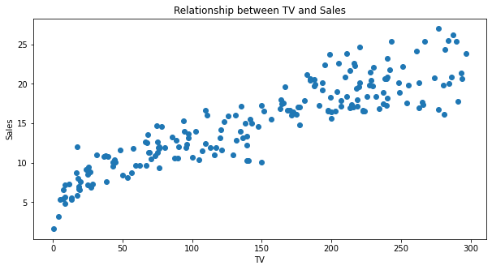

```python
# Visualise the relationship between the features and the response using scatterplots

plt.figure(figsize=(10,5))

plt.scatter(X,y)

plt.title('Relationship between TV and Sales')

plt.xlabel('TV')
plt.ylabel('Sales')
plt.show()
```

- As TV's value increases sales increases vise-versa
  - i.e shows positive linear relation

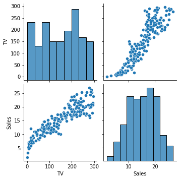

```python
# plot a pairplot also for df

sns.pairplot(df)
```

- Same shows positive linear relation between both TV and Sales

# Checking dimensions of X and y

```python
# Print the dimensions of X and y
print(X.shape)
print(y.shape)
```

```
(200,)
(200,)
```

```python
X
```

```
0      230.1
1       44.5
2       17.2
3      151.5
4      180.8
       ...
195     38.2
196     94.2
197    177.0
198    283.6
199    232.1
Name: TV, Length: 200, dtype: float64
```

```python
y
```

```
0      22.1
1      10.4
2      12.0
3      16.5
4      17.9
       ...
195     7.6
196    14.0
197    14.8
198    25.5
199    18.4
Name: Sales, Length: 200, dtype: float64
```

# Reshaping X and y

- Since we are working with only one feature variable, so we need to reshape using Numpy reshape() method

`Example`: If you have an array of shape (3,2) then reshaping it with (-1, 1), then the array will get reshaped in such a way that the resulting array has only 1 column and this is only possible by having 6 rows, hence, (6,1)

```python
# Reshape X and y
X = np.array(X)
X = np.reshape(X,(-1,1))

y = np.array(y)
y = np.reshape(y,(-1,1))
```

```python
# Print the dimensions of X and y after reshaping
print(X.shape)
print(y.shape)
```

```
(200, 1)
(200, 1)
```

```python
# run it if you want

#X
```

```python
# run it if you want

#y
```

# Difference in dimensions of X and y after reshaping

You can see the difference in diminsions of X and y before and after reshaping.

It is essential in this case because getting the feature and target variable right is an important precursor to model building.

# Performing Simple Linear Regression

Linear Regression Equation `y = c + m_1x_1 + m_2x_2 + ... + m_nx_n`

- $y$ is the response
- $c$ is the intercept
- $m_1$ is the coefficient for the first feature
- $m_n$ is the coefficient for the nth feature

In our case: `$y = c + m_1 \times TV$`

$m$ = model **coefficients** or **model parameters**

# Mechanics of the model

- It is good to understand the generic structure of modeling using scikit-learn library
- Broad steps to build any model can be divided as follows:
  - Split dataset into two sets – training set and test set
  - Instantiate regressor lm and fit it on training set with fit method
  - In above step model learned relationships between training data (X_train, y_train)
- Now model is ready to make predictions on test data (X_test)
- So predict on test data using predict method

# Train test split

- Split dataset into two sets namely - train set and test set
- Model learn relationships from training data and predict on test data

```python
# import train_test_split module
from sklearn.model_selection import train_test_split

# Split X and y into training and test data sets with test_size=0.3 and random_state=42

X_train,y_train,X_test,y_test = train_test_split(X,y,test_size=0.3,random_state=42)
```

```python
# print shapes of X_train,y_train, X_test, y_test

print(X_train.shape)
print(X_test.shape)
print(y_train.shape)
print(y_test.shape)
```

```
(140, 1)
(140, 1)
(60, 1)
(60, 1)
```

```python
# import LinearRegression module
from sklearn.linear_model import LinearRegression as lir


# Instantiate the linear regression object lm
lm = lir()
# Fit and train the model using training data sets
lm.fit(X_train,X_test)
# Predict on the test data
y_pred_test = lm.predict(y_train)
```

# Model slope and intercept term

- `Model slope is given by lm.coef_`
- `Model intercept is given by lm.intercept_.`

`For example`:  
if estimated model slope and intercept values are 1.60509347 and -11.16003616

So, equation of fitted regression line will be:-

`y = 1.60509347 * x - 11.16003616`

```python
# Compute model slope and intercept
print('Estimated model slope, a: {}'.format(lm.coef_))
print('Estimated model intercept, b: {}'.format(lm.intercept_))
```

```
Estimated model slope, a: [[0.05483488]]
Estimated model intercept, b: [7.20655455]
```

```python
# So comment below, our fitted regression line here is ?

y = 0.05483488 * X + 7.20655455
```

Above is the Linear Model

# Making predictions

To make prediction on an individual TV value,

```
            lm.predict(Xi)
```

where:

`Xi` = `TV data value of ith observation`

```python
df.TV.head()
```

```
0    230.1
1     44.5
2     17.2
3    151.5
4    180.8
Name: TV, dtype: float64
```

```python
# Predicting Sales values on first five 5 TV  datasets only
pred_x = lm.predict(X)
pred_x[:5]
```

```
array([[19.82406131],
       [ 9.64670688],
       [ 8.14971455],
       [15.51403944],
       [17.12070154]])
```

Can also do prediction for all values of TV available in dataset

```python
# prediction for all X present in the dataset

# if you want to see it remove # from pred_x
#pred_x
```

# `Model Performance`

### `Regression Metrics`

To Evaluate Model Performance

For Regression Problems there are two ways to Compute Model Performance

1. **`RMSE (Root Mean Square Error)`**
   - RMSE is standard deviation of residuals, it gives us standard deviation of unexplained variance by model \
   - It results in lower values of RMSE as `lower values of RMSE indicate better fit of data`

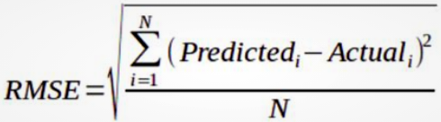

2. **`R-Squared Value`**
   - `(R2) Correlation` explains strength of relationship between an independent and dependent variable
   - `R-square` explains to what extent variance of one variable explains variance of second variable. It may also be known as the coefficient of determination
   - `If R2 of a model is 0.50, then approximately half of observed variation can be explained by model's inputs`
   - `Its value can become negative if our model is wrong`

[Important Link](http://www.fairlynerdy.com/what-is-r-squared/)

```python
# import mean_squared_error module
from sklearn.metrics import mean_squared_error as mse


# Calculate and print Root Mean Square Error(RMSE)
mse = mse(y_test,y_pred_test)
rmse = np.sqrt(mse)

print(f'RMSE value:: {rmse}')
```

```
RMSE value:: 2.2758570698017597
```

```python
# import r2_score module
from sklearn.metrics import r2_score


# Calculate and print r2_score
r2 = r2_score(y_test,y_pred_test)
print(f'R2 Score value:: {r2 }')
```

```
R2 Score value:: 0.814855389208679
```

# Interpretation and Conclusion

[figure not shown]

```python
# Plot the Regression Line between X and Y as shown in below output.

plt.figure(figsize=(20,8))
plt.scatter(y_train,y_test,color='blue',label='Scatter Plot')
plt.plot(y_train,y_pred_test,color='red',linewidth=4,label='Regression Line')

plt.legend(loc=4)
plt.title('Sales and Advertising Relation')
plt.xlabel('Sales')
plt.ylabel('Advertising')

plt.show()
```

- RMSE value has been found to be 2.2758
  - Means standard Deviation for our prediction is 2.2758 which is quite less
- Sometimes we can also expect RMSE to be less than 2.2758 ,can say model is good fit to data
- Our R2 score value has been found to be 0.814855389208679
  - `It means that this model explains 81.49 % of the variance in our dependent variable`
  - So R2 score value confirms that the model is good enough to deploy because it provides good fit to data
- See in figure Regression line fits data quite well

# Residual analysis

- Linear regression model may not represent data appropriately, model may be a poor fit to data
  - So we should validate our model by defining and examining residual plots
  - `Difference between observed value of dependent variable (y) and predicted value (ŷi) is called residual and is denoted by e or error`
  - Scatter-plot of these residuals is called residual plot

If data points in a residual plot are randomly dispersed around horizontal axis and an approximate zero residual mean, a linear regression model may be appropriate for data. Otherwise a non-linear model may be more appropriate

If we take a look at both generated ‘Residual errors’ plot(below), we can clearly see that train data plot pattern is non-random. Same is the case with the test data plot pattern. So, it suggests a better-fit for a non-linear model

```python
X_test.shape,X_train.shape,y_train.shape,y_test.shape
```

```
((140, 1), (140, 1), (60, 1), (60, 1))
```

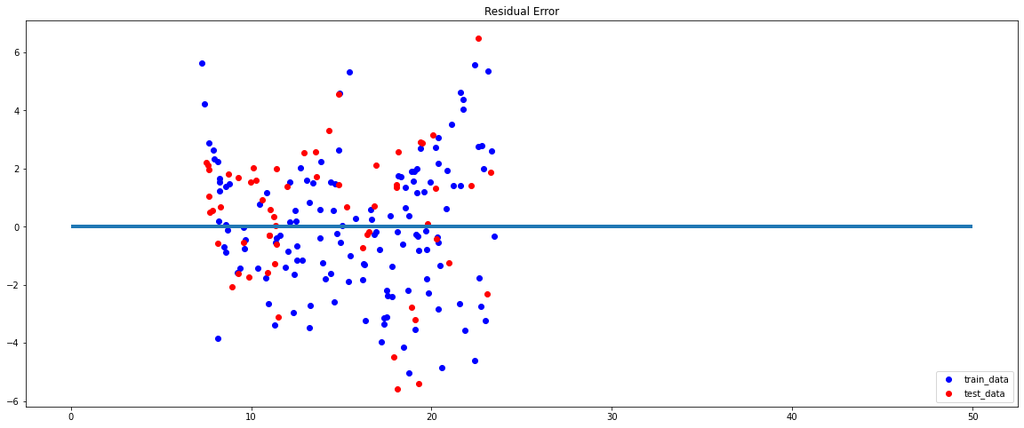

```python
# Plotting residual errors

plt.figure(figsize=(20,8))
plt.scatter(lm.predict(X_train),lm.predict(X_train) - X_test,color='blue',label='train_data')
plt.scatter(lm.predict(y_train),lm.predict(y_train) - y_test,color='red',label='test_data')

plt.hlines(xmin=0,xmax=50,y=0,linewidth=4)
plt.legend(loc=4)
plt.title('Residual Error')

plt.show()
```

# Checking for Overfitting and Underfitting

Will see training set score and test set score

- Can expect training set score to be 0.7996 which is averagely good. So, model learned relationships quite appropriately from training data
- Model performs good on test data as test score will be 0.8149
  - It is a clear sign of good fit/ balanced fit
  - Hence, we can validated our finding that linear regression model provides good fit to data

**`Underfitting:`**

- Model underfitts training data when model performs poorly on training data
- This is because model is unable to capture relationship between input examples (often called X) and target values (often called Y)

**`Overfitting:`**

- Model overfitts training data when you see that model performs well on training data but does not perform well on evaluation data
- This is because model is memorizing data it has seen and is unable to generalize to unseen examples

[More into Over/Under fitting](https://www.pinterest.com/pin/791155859531008328/)

```python
# Checking for Overfitting or Underfitting the data by calculation score using score function.
print(f'Training set score:: {lm.score(X_train,X_test)}')
print(f'Test set score:: {lm.score(y_train,y_test)}')
```

```
Training set score:: 0.799626928219267
Test set score:: 0.814855389208679
```